# 4b_artikel_beoordelen_op_reproduceerbaarheid

2026-04-22

## Gekozen artikel

Het artikel dat onderzocht wordt is ‘Infectivity and fatality of influenza in pre- and post-COVID-19 pandemic year’, geschreven door Shuanglin Jing en Hao Wang.  
Link naar artikel: https://journals.plos.org/ploscompbiol/article?id=10.1371/journal.pcbi.1013229

### Onderzoeksvraag:

De onderzoeksvraag is: Hoe zijn de epidemiologische kenmerken van influenza veranderd tussen de periode vóór en na de pandemie?

### Methode:

Er zijn twee wiskundige modellen gebruikt om de transmissie- en sterftecijfers van influenza in te schatten. Het eerste model is een leeftijdsgestructureerd model waarbij de populatie in meerdere leeftijdsgroepen worden verdeeld, Elke groep wordt vervolgens onderverdeeld in de subklassen vatbaar, latent, geïnfecteerd, hersteld en overleden. Het tweede model is een multistammenmodel dat de transmissie- en sterftecijfers van meerdere influenzastammen binnen de gehele populatie beschouwt. Beide modellen bevatten tijdsafhankelijke parameters om de variabiliteit in influenzatransmissie en -ernst weer te geven.

### Resultaten:

-De transmissiesnelheid van influenza onder de bevolking van 18 jaar en ouder was in het laatste jaar van de COVID-19-pandemie (2022-2023) relatief laag.  
-In het eerste jaar na de pandemie (2023-2024) was de transmissiesnelheid in deze leeftijdsgroep weer gestegen tot het niveau van vóór de pandemie.  
-Bij personen onder de 18 jaar bleef de transmissiesnelheid stabiel.  
-Bij influenza a waren deze verschillen groter dan bij influenza b.  
-In 2022-2023 vertoonden de grieptesterftecijfers verhoogde niveaus bij alle 3 de leeftijdscategorieën (0-17 jaar, 18-64 jaar en 65-plussers). In 2023-2024 daalden de sterftecijfers door influenza in alle drie de leeftijdsgroepen terug naar het niveau van vóór de pandemie.

## Beoordelingscriteria voor reproduceerbaarheid

| Transparency.Criteria | Response |
| --- | --- |
| Study Purpose | Yes |
| Data Availability Statement | Yes |
| Data Location | Yes |
| Study Location | Yes |
| Author Review | Yes |
| Funding Statement | Yes |
| Code Availability | Yes |

## Reproduceerbaarheid van de gedeelde R code

-Er is een bestand genaamd README toegevoegd aan de repository, maar deze is niet ingevuld. Dit maakt het lastig om te bepalen welke bestanden nodig zijn. -Het artikel staat in de website onder artikelen die R code bevatten, maar in werkelijkheid is er gebruik gemaakt van analyse in MATLAB, wat te zien is aan het gebruik van .m en .mat bestanden. Dit maakt volledige analyse in Rstudio niet mogelijk. -Er zijn wel .csv en .xlsx bestanden beschikbaar. Deze zijn al in tidy format gezet. / Ik heb geprobeerd om figuur 1E zoveel mogleijk te produceren in Rstdudio. Hiervoor heb ik het bestand Death data(18-64).xlsx gebruikt. Dit bestand is hier te vinden: / https://github.com/shuanglinjing/Long-COVID-impact-on-influenza-infectivity-and-fatality/blob/master/Transmission%20and%20mortality%20rates%20of%20age%20structure%20model/Death%20data(18-64).xlsx

### Importeer de dataset Death data(18-64).xlsx

```r
# Laad de libraries tidyverse en readxl
library(tidyverse)
library(readxl)

# Importeer het bestand Death data(18-64).xlsx in Rstudio
death_data_18_64 <-read_excel("~/dsfb2/dsfb2_workflows_portfolio/dsfb2_workflows_portfolio/projecten/4b_artikel_beoordelen_op_reproduceerbaarheid/Death data(18-64).xlsx")
```

### Selecteren en filteren van data

Selecteer de volgende data:  
-SEASON: 2023-24  
-WEEK: 40, 43, 46, 49, 52, 3, 6, 9, 12 en 15  
-NUM INFLUENZA DEATHS die bij deze rijen horen

```r
library(dplyr)

# Definieer de gewenste weekvolgorde
week_order <- c(40, 43, 46, 49, 52, 3, 6, 9, 12, 15)

# Selecteer en filter de volgende data:
## SEASON: 2023-24
## WEEK: 40, 43, 46, 49, 52, 3, 6, 9, 12 en 15
## NUM INFLUENZA DEATHS die bij deze rijen horen
fig1e_data <- death_data_18_64 %>%
  filter(
    SEASON == "2023-24",
    WEEK %in% week_order
  ) %>%
  mutate(
    WEEK = factor(WEEK, levels = week_order)
  ) %>%
  arrange(WEEK) %>%
  select(
    SEASON,
    WEEK,
    `NUM INFLUENZA DEATHS`
  )

# Controleer of de juiste data is geselecteerd
fig1e_data
```

```
## # A tibble: 10 × 3
##    SEASON  WEEK  `NUM INFLUENZA DEATHS`
##    <chr>   <fct>                  <dbl>
##  1 2023-24 40                         6
##  2 2023-24 43                         7
##  3 2023-24 46                        29
##  4 2023-24 49                        69
##  5 2023-24 52                       252
##  6 2023-24 3                        190
##  7 2023-24 6                        117
##  8 2023-24 9                        100
##  9 2023-24 12                        61
## 10 2023-24 15                        48
```

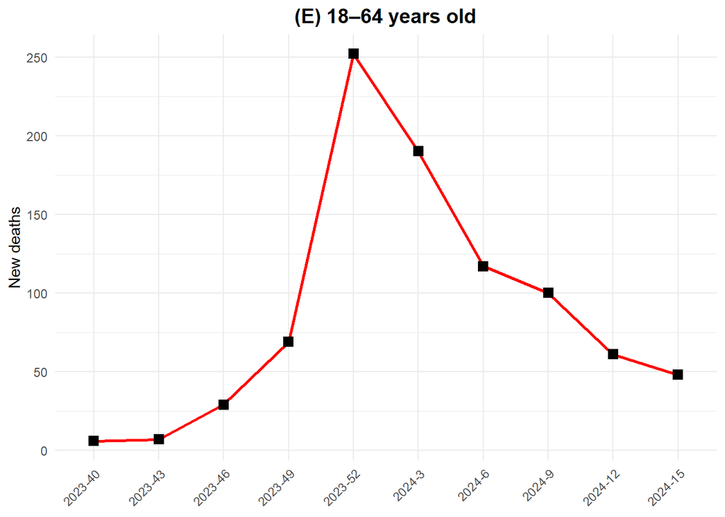

```r
library(ggplot2)
library(dplyr)

# Definieer weekvolgorde
week_order <- c(40, 43, 46, 49, 52, 3, 6, 9, 12, 15)

# Voeg x-as labels toe (jaar-week)
fig1e_plot_data <- fig1e_data %>%
  mutate(
    WEEK = factor(WEEK, levels = week_order),
    YEAR_WEEK = case_when(
      WEEK %in% c(40, 43, 46, 49, 52) ~ paste0("2023-", WEEK),
      WEEK %in% c(3, 6, 9, 12, 15) ~ paste0("2024-", WEEK)
    ),
    YEAR_WEEK = factor(YEAR_WEEK, levels = unique(YEAR_WEEK))
  )

# Maak de plot
ggplot(fig1e_plot_data,
       aes(x = YEAR_WEEK,
           y = `NUM INFLUENZA DEATHS`,
           group = 1)) +
  geom_line(color = "red", linewidth = 1) +
  geom_point(shape = 15, size = 3, color = "black") +
  scale_y_continuous(
    name = "New deaths",
    breaks = seq(0, max(fig1e_plot_data$`NUM INFLUENZA DEATHS`, na.rm = TRUE), by = 50)
  ) +
  labs(
    x = NULL,
    title = "(E) 18–64 years old"
  ) +
  theme_minimal() +
  theme(
    plot.title = element_text(hjust = 0.5, size = 14, face = "bold"),
    axis.text.x = element_text(angle = 45, hjust = 1)
  )
```

```r
library(dplyr)

# Definieer correcte weekvolgorde
week_order <- c(40:52, 1:15)

fig1e_data <- death_data_18_64 %>%
  filter(
    SEASON == "2023-24",
    WEEK %in% week_order
  ) %>%
  mutate(
    WEEK = factor(WEEK, levels = week_order)
  ) %>%
  arrange(WEEK) %>%
  select(
    SEASON,
    WEEK,
    `NUM INFLUENZA DEATHS`
  )

# Bekijk de geselecteerde data
fig1e_data
```

```
## # A tibble: 28 × 3
##    SEASON  WEEK  `NUM INFLUENZA DEATHS`
##    <chr>   <fct>                  <dbl>
##  1 2023-24 40                         6
##  2 2023-24 41                        12
##  3 2023-24 42                        11
##  4 2023-24 43                         7
##  5 2023-24 44                        21
##  6 2023-24 45                        17
##  7 2023-24 46                        29
##  8 2023-24 47                        42
##  9 2023-24 48                        38
## 10 2023-24 49                        69
## # ℹ 18 more rows
```